# 08_EDA_AdultCensus

María - Pérez - Bootcamp NEOLAND

11 noviembre, 2020

## Objetivo de la tarea

Aplicando lo aprendido durante las clases, el objetivo de la actividad será realizar un análisis exploratorio de datos completo sobre un dataset del censo de adultos del año 1994, incluyendo los pasos de exploración, limpieza y discretización de variables.

## Preparación previa

Empezaremos cargando el dataset, como paso previo al procesado debemos tener algunas consideraciones a la hora de cargar nuestros datos:

- El dataset representa los valores perdidos con el caracter “?”, por lo tanto para que esos valores se cargen en R como NAs tenemos que usar el parámetro `na.strings` para indicarle el valor que representa los NAs en el dataset.
- Usamos la opción `strip.white` para quitar espacios en blanco que puedan afectar al procesamiento de los datos,
- Pondremos el parámetro `stringsAsFactors` como False, ya que todas las variables no deben ser entendidas por defecto como factores, si no convertidas algunas de ellas más adelante si consideramos que es necesario y conveniente al realizar el análisis y la exploración de los datos.

```r
# Cargamos el dataset con la función `read.csv`.
data_adult <- read.csv(
  'http://archive.ics.uci.edu/ml/machine-learning-databases/adult/adult.data',
  stringsAsFactors = FALSE,
  header = FALSE,
  na.strings = "?",
  strip.white = TRUE
  )
```

Además, como parte de la preparación del dataset, asignaremos nombres a las distintas columnas a partir de un array y cargaremos las librerías que usaremos a lo largo de la tarea (en este caso, `ggplot2` y `dplyr`).

```r
# Asignamos nombres a los atributos con la función `names`.
names(data_adult) <- c("age","workclass","fnlwgt","education","education-num","marital-status","occupation","relationship","race","sex","capital-gain","capital-loss","hour-per-week","native-country","income")

# Cargamos las librerías a utilizar.
library(ggplot2)
library(dplyr)
```

## Exploración de los datos

Comenzando con el análisis del dataset, vemos con la función `dim` que está compuesto por 32561 observaciones distribuidas en 15 variables, además exploramos la existencia de NA’s y strings vacías. Observamos que los atributos `workclass`, `occupation` y `native-country` contienen una gran cantidad de valores NA’s. No se observan por otra parte valores con strings vacíos.

```r
# Dimensiones del dataset.
dim(data_adult)
```

```
## [1] 32561    15
```

```r
# Comprobamos NAs y strings vacíos.
colSums(is.na(data_adult))
```

```
##            age      workclass         fnlwgt      education  education-num
##              0           1836              0              0              0
## marital-status     occupation   relationship           race            sex
##              0           1843              0              0              0
##   capital-gain   capital-loss  hour-per-week native-country         income
##              0              0              0            583              0
```

```r
# Forzamos con el parámetro na.rm para que se pueda calcular la suma a pesar de los NA's.
colSums(data_adult == "", na.rm = T)
```

```
##            age      workclass         fnlwgt      education  education-num
##              0              0              0              0              0
## marital-status     occupation   relationship           race            sex
##              0              0              0              0              0
##   capital-gain   capital-loss  hour-per-week native-country         income
##              0              0              0              0              0
```

Podemos extraer también el listado de las columnas o etiquetas y comprobar el número de filas (en este caso, 32561).

```r
# Extraemos el listado de las columnas
ls(data_adult)
```

```
##  [1] "age"            "capital-gain"   "capital-loss"   "education"
##  [5] "education-num"  "fnlwgt"         "hour-per-week"  "income"
##  [9] "marital-status" "native-country" "occupation"     "race"
## [13] "relationship"   "sex"            "workclass"
```

```r
# También las etiquetas.
names(data_adult)
```

```
##  [1] "age"            "workclass"      "fnlwgt"         "education"
##  [5] "education-num"  "marital-status" "occupation"     "relationship"
##  [9] "race"           "sex"            "capital-gain"   "capital-loss"
## [13] "hour-per-week"  "native-country" "income"
```

```r
# Comprobamos el número de filas.
nrow(data_adult)
```

```
## [1] 32561
```

Para tener una visión global de los datos, con la función `summary` sacaremos un resumen estadístico global. Este resumen incluye medidas de tendencia central, de posición y algunas medidas de dispersión.

```r
summary(data_adult)
```

```
##       age         workclass             fnlwgt         education
##  Min.   :17.00   Length:32561       Min.   :  12285   Length:32561
##  1st Qu.:28.00   Class :character   1st Qu.: 117827   Class :character
##  Median :37.00   Mode  :character   Median : 178356   Mode  :character
##  Mean   :38.58                      Mean   : 189778
##  3rd Qu.:48.00                      3rd Qu.: 237051
##  Max.   :90.00                      Max.   :1484705
##  education-num   marital-status      occupation        relationship
##  Min.   : 1.00   Length:32561       Length:32561       Length:32561
##  1st Qu.: 9.00   Class :character   Class :character   Class :character
##  Median :10.00   Mode  :character   Mode  :character   Mode  :character
##  Mean   :10.08
##  3rd Qu.:12.00
##  Max.   :16.00
##      race               sex             capital-gain    capital-loss
##  Length:32561       Length:32561       Min.   :    0   Min.   :   0.0
##  Class :character   Class :character   1st Qu.:    0   1st Qu.:   0.0
##  Mode  :character   Mode  :character   Median :    0   Median :   0.0
##                                        Mean   : 1078   Mean   :  87.3
##                                        3rd Qu.:    0   3rd Qu.:   0.0
##                                        Max.   :99999   Max.   :4356.0
##  hour-per-week   native-country        income
##  Min.   : 1.00   Length:32561       Length:32561
##  1st Qu.:40.00   Class :character   Class :character
##  Median :40.00   Mode  :character   Mode  :character
##  Mean   :40.44
##  3rd Qu.:45.00
##  Max.   :99.00
```

Ya teniendo una imagen global de los datos estadísticos de nuestro dataset, podemos explorar algunos valores estadísticos, así como visualizar tablas de frecuencias de algunos datos concretos.

```r
# Cálculos estadísticos sobre columnas concretas.
# Media de edad de los adultos de la muestra.
mean(data_adult$age)
```

```
## [1] 38.58165
```

```r
# Máximo de edad de los adultos de la muestra.
max(data_adult$age)
```

```
## [1] 90
```

```r
# Mínimo de edad de los adultos de la muestra.
min(data_adult$age)
```

```
## [1] 17
```

```r
# Tabla de frecuencias absolutas de los adultos por sexo.
table(data_adult$sex)
```

```
##
## Female   Male
##  10771  21790
```

## Preparación de los datos

Realizaremos algunas operaciones previas sobre los datos antes de pasar a la fase de limpieza. Recategorizamos la columna “education”:

```r
# Calculamos el número de filas.
filas= nrow(data_adult)

# Creamos tres vectores para reasignar los valores de la columna "education".
E18=c("Preschool","1st-4th","5th-6th","7th-8th","9th","10th" ,"11th","12th")
E912=c("HS-grad","Some-college","Assoc-acdm","Assoc-voc")
E1316=c("Bachelors","Masters","Prof-school","Doctorate")

# Iteramos sobre el total de filas.
 for (i in 1:filas){
if (data_adult$education[i] %in% E18){
  data_adult$education[i] = "E18"
} else if(data_adult$education[i] %in% E912){
  data_adult$education[i] = "E912"
} else if (data_adult$education[i] %in% E1316){
  data_adult$education[i] = "E1316"
}
 }

# Mostramos la distribución de frecuencias absolutas del atributo "education".
table(data_adult$education)
```

```
##
## E1316   E18  E912
##  8067  4253 20241
```

Ahora vamos a crear una nueva columna basada en “hour-per-week” que puede resultarnos útil para el análisis posterior de los datos. Para ello sacaremos la tabla de frecuencias para examinar como se distribuyen los valores en esta variable.

```r
# Tabla de frecuencias de valores relativos redondeando con tres decimales.
round(prop.table(table(data_adult$`hour-per-week`)), 2)
```

```
##
##    1    2    3    4    5    6    7    8    9   10   11   12   13   14   15   16
## 0.00 0.00 0.00 0.00 0.00 0.00 0.00 0.00 0.00 0.01 0.00 0.01 0.00 0.00 0.01 0.01
##   17   18   19   20   21   22   23   24   25   26   27   28   29   30   31   32
## 0.00 0.00 0.00 0.04 0.00 0.00 0.00 0.01 0.02 0.00 0.00 0.00 0.00 0.04 0.00 0.01
##   33   34   35   36   37   38   39   40   41   42   43   44   45   46   47   48
## 0.00 0.00 0.04 0.01 0.00 0.01 0.00 0.47 0.00 0.01 0.00 0.01 0.06 0.00 0.00 0.02
##   49   50   51   52   53   54   55   56   57   58   59   60   61   62   63   64
## 0.00 0.09 0.00 0.00 0.00 0.00 0.02 0.00 0.00 0.00 0.00 0.05 0.00 0.00 0.00 0.00
##   65   66   67   68   70   72   73   74   75   76   77   78   80   81   82   84
## 0.01 0.00 0.00 0.00 0.01 0.00 0.00 0.00 0.00 0.00 0.00 0.00 0.00 0.00 0.00 0.00
##   85   86   87   88   89   90   91   92   94   95   96   97   98   99
## 0.00 0.00 0.00 0.00 0.00 0.00 0.00 0.00 0.00 0.00 0.00 0.00 0.00 0.00
```

```r
# Vamos a categorizar cada persona en función del número de horas que trabaja en cuatro categorías:
# Sporadic, Part-time, Full-Time y Overwork
for (i in 1:filas) {
  if (data_adult$`hour-per-week`[i] <= 15) {
    data_adult$`work-hours`[i] <- "Sporadic"
  } else if (data_adult$`hour-per-week`[i] <= 30 ) {
    data_adult$`work-hours`[i] <- "Part-Time"
  } else if (data_adult$`hour-per-week`[i] <= 45) {
    data_adult$`work-hours`[i] <- "Full-Time"
  } else {
    data_adult$`work-hours`[i] <- "Overwork"
  }
}

# Convertimos a factor la nueva columna.
data_adult$`work-hours` <- as.factor(data_adult$`work-hours`)

# Mostramos las frecuencias relativas de las nuevas categorías.
round(prop.table(table(data_adult$`work-hours`)), 2)
```

```
##
## Full-Time  Overwork Part-Time  Sporadic
##      0.62      0.22      0.12      0.04
```

### Limpieza

En este apartado analizaremos las frecuencias absolutas y relativas de cada uno de los atributos que vimos previamente en el análisis exploratorio que contenían NAs. Luego procederemos a imputar los mismos. Empezaremos con el atributo `workclass`, que podemos ver que tiene un total de 1836 NAs:

```r
# Comprobación del total de NAs en el atributo a través de la función `sum` y `is.na`.
sum(is.na(data_adult$workclass))
```

```
## [1] 1836
```

```r
# Tabla de frecuencias de valores absolutos.
table(data_adult$workclass)
```

```
##
##      Federal-gov        Local-gov     Never-worked          Private
##              960             2093                7            22696
##     Self-emp-inc Self-emp-not-inc        State-gov      Without-pay
##             1116             2541             1298               14
```

```r
# Tabla de frecuencias de valores relativos redondeando con dos decimales.
round(prop.table(table(data_adult$workclass)), 2)
```

```
##
##      Federal-gov        Local-gov     Never-worked          Private
##             0.03             0.07             0.00             0.74
##     Self-emp-inc Self-emp-not-inc        State-gov      Without-pay
##             0.04             0.08             0.04             0.00
```

En base al resultado obtenido, decidimos imputar los NAs del atributo `workclass` por la moda, ya que existe una mayoría de instancias en una alternativa concreta (en este caso, `Private`, que tiene una frecuencia relativa de 0.74).

```r
# Imputamos los NAs.
data_adult$workclass[is.na(data_adult$workclass)] <- "Private"

# Visualizamos las frecuencias de valores absolutos tras la imputación de NAs.
table(data_adult$workclass)
```

```
##
##      Federal-gov        Local-gov     Never-worked          Private
##              960             2093                7            24532
##     Self-emp-inc Self-emp-not-inc        State-gov      Without-pay
##             1116             2541             1298               14
```

```r
# Comprobamos que no hay NAs en la columna.
sum(is.na(data_adult$workclass))
```

```
## [1] 0
```

Pasamos a analizar los NAs del atributo `occupation`, que cuenta con 1843 NAs:

```r
# Comprobación del total de NAs en el atributo a través de la función `sum` y `is.na`.
sum(is.na(data_adult$occupation))
```

```
## [1] 1843
```

```r
# Tabla de frecuencias de valores absolutos.
table(data_adult$occupation)
```

```
##
##      Adm-clerical      Armed-Forces      Craft-repair   Exec-managerial
##              3770                 9              4099              4066
##   Farming-fishing Handlers-cleaners Machine-op-inspct     Other-service
##               994              1370              2002              3295
##   Priv-house-serv    Prof-specialty   Protective-serv             Sales
##               149              4140               649              3650
##      Tech-support  Transport-moving
##               928              1597
```

```r
# Tabla de frecuencias de valores relativos redondeando con dos decimales.
round(prop.table(table(data_adult$occupation)), 2)
```

```
##
##      Adm-clerical      Armed-Forces      Craft-repair   Exec-managerial
##              0.12              0.00              0.13              0.13
##   Farming-fishing Handlers-cleaners Machine-op-inspct     Other-service
##              0.03              0.04              0.07              0.11
##   Priv-house-serv    Prof-specialty   Protective-serv             Sales
##              0.00              0.13              0.02              0.12
##      Tech-support  Transport-moving
##              0.03              0.05
```

En base a los resultados que vemos en las tablas de frecuencias, decidimos imputar los NAs del atributo `occupation` por valores aleatorios, ya que existe una distribución de los datos bastante uniforme entre las distintas alternativas. Utilizamos para ello la función `sample` que genera valores aleatorios.

```r
# Imputamos los NAs.

# Creamos un vector con los nombres de los posibles valores que asignaremos aleatoriamente.
possible_values <- c("Adm-clerical", "Armed-Forces", "Craft-repair", "Exec-managerial", "Farming-fishing", "Handlers-cleaners", "Machine-op-inspct", "Other-service", "Priv-house-serv", "Prof-specialty", "Protective-serv", "Sales", "Tech-support", "Transport-moving")

# Creamos una variable con el número de NAs que hay en la columna "occupation".
num_na <- sum(is.na(data_adult$occupation))

# Aplicamos la función sample que genera valores aleatorios (en este caso, entre los valores posibles
# que previamente le hemos dado). Generará el número de valores aleatorios que le hemos pasado como
# num_na y, con el parámetro de replace = T, indicaremos que el valor escogido pueda volver a salir.
# Guardamos el resultado en una variable.
random_values <- sample(possible_values, num_na, replace = T)

# Finalmente, sustituimos los NAs de la columna occupation por los valores recogidos en la variable
# random_values.
data_adult$occupation[is.na(data_adult$occupation)] <- random_values

# Comprobamos que no hay NAs en la columna.
sum(is.na(data_adult$occupation))
```

```
## [1] 0
```

Una vez resuelto lo anterior, pasamos a analizar con el mismo procedimiento el último atributo que presenta valores NAs (`native-country`), este atributo presenta 583 NAs:

```r
# Comprobación del total de NAs en el atributo a través de la función `sum` y `is.na`.
sum(is.na(data_adult$`native-country`))
```

```
## [1] 583
```

```r
# Tabla de frecuencias de valores absolutos.
table(data_adult$`native-country`)
```

```
##
##                   Cambodia                     Canada
##                         19                        121
##                      China                   Columbia
##                         75                         59
##                       Cuba         Dominican-Republic
##                         95                         70
##                    Ecuador                El-Salvador
##                         28                        106
##                    England                     France
##                         90                         29
##                    Germany                     Greece
##                        137                         29
##                  Guatemala                      Haiti
##                         64                         44
##         Holand-Netherlands                   Honduras
##                          1                         13
##                       Hong                    Hungary
##                         20                         13
##                      India                       Iran
##                        100                         43
##                    Ireland                      Italy
##                         24                         73
##                    Jamaica                      Japan
##                         81                         62
##                       Laos                     Mexico
##                         18                        643
##                  Nicaragua Outlying-US(Guam-USVI-etc)
##                         34                         14
##                       Peru                Philippines
##                         31                        198
##                     Poland                   Portugal
##                         60                         37
##                Puerto-Rico                   Scotland
##                        114                         12
##                      South                     Taiwan
##                         80                         51
##                   Thailand            Trinadad&Tobago
##                         18                         19
##              United-States                    Vietnam
##                      29170                         67
##                 Yugoslavia
##                         16
```

```r
# Tabla de frecuencias de valores relativos redondeando con dos decimales.
round(prop.table(table(data_adult$`native-country`)), 2)
```

```
##
##                   Cambodia                     Canada
##                       0.00                       0.00
##                      China                   Columbia
##                       0.00                       0.00
##                       Cuba         Dominican-Republic
##                       0.00                       0.00
##                    Ecuador                El-Salvador
##                       0.00                       0.00
##                    England                     France
##                       0.00                       0.00
##                    Germany                     Greece
##                       0.00                       0.00
##                  Guatemala                      Haiti
##                       0.00                       0.00
##         Holand-Netherlands                   Honduras
##                       0.00                       0.00
##                       Hong                    Hungary
##                       0.00                       0.00
##                      India                       Iran
##                       0.00                       0.00
##                    Ireland                      Italy
##                       0.00                       0.00
##                    Jamaica                      Japan
##                       0.00                       0.00
##                       Laos                     Mexico
##                       0.00                       0.02
##                  Nicaragua Outlying-US(Guam-USVI-etc)
##                       0.00                       0.00
##                       Peru                Philippines
##                       0.00                       0.01
##                     Poland                   Portugal
##                       0.00                       0.00
##                Puerto-Rico                   Scotland
##                       0.00                       0.00
##                      South                     Taiwan
##                       0.00                       0.00
##                   Thailand            Trinadad&Tobago
##                       0.00                       0.00
##              United-States                    Vietnam
##                       0.91                       0.00
##                 Yugoslavia
##                       0.00
```

En vista de los resultados, y al igual que en el caso del atributo `workclass`, al existir una alternativa en la que claramente se registran la mayoría de datos, optamos por elegir la moda como método de imputación de los NAs de este atributo. En este caso la moda es `United-States`.

```r
# Imputamos los NAs.
data_adult$`native-country`[is.na(data_adult$`native-country`)] <- "United-States"

# Visualizamos las frecuencias de valores absolutos tras la imputación de NAs.
table(data_adult$`native-country`)
```

```
##
##                   Cambodia                     Canada
##                         19                        121
##                      China                   Columbia
##                         75                         59
##                       Cuba         Dominican-Republic
##                         95                         70
##                    Ecuador                El-Salvador
##                         28                        106
##                    England                     France
##                         90                         29
##                    Germany                     Greece
##                        137                         29
##                  Guatemala                      Haiti
##                         64                         44
##         Holand-Netherlands                   Honduras
##                          1                         13
##                       Hong                    Hungary
##                         20                         13
##                      India                       Iran
##                        100                         43
##                    Ireland                      Italy
##                         24                         73
##                    Jamaica                      Japan
##                         81                         62
##                       Laos                     Mexico
##                         18                        643
##                  Nicaragua Outlying-US(Guam-USVI-etc)
##                         34                         14
##                       Peru                Philippines
##                         31                        198
##                     Poland                   Portugal
##                         60                         37
##                Puerto-Rico                   Scotland
##                        114                         12
##                      South                     Taiwan
##                         80                         51
##                   Thailand            Trinadad&Tobago
##                         18                         19
##              United-States                    Vietnam
##                      29753                         67
##                 Yugoslavia
##                         16
```

```r
# Comprobamos que no hay NAs en la columna.
sum(is.na(data_adult$`native-country`))
```

```
## [1] 0
```

### Discretización

```r
# Realizamos la factorización del atributo.
data_adult_cols <- c("age", "workclass", "fnlwgt", "education", "education-num", "marital-status", "occupation", "relationship", "race", "sex", "capital-gain", "capital-loss", "hour-per-week", "native-country", "income")

# Iteramos sobre el vector previamente creado y convertimos en factor cada columna.
for (i in data_adult_cols){
  data_adult[,i] = as.factor(data_adult[,i])
}
```

## Visualizaciones del análisis de los datos

Una vez limpiados los datos y discretizadas las variables, crearemos algunas visualizaciones que nos servirán para el análisis de nuestros datos. Analizaremos por ejemplo la interacción entre el atributo “income” (el cual hace referencia a los ingresos económicos) y otros como el sexo o la raza.

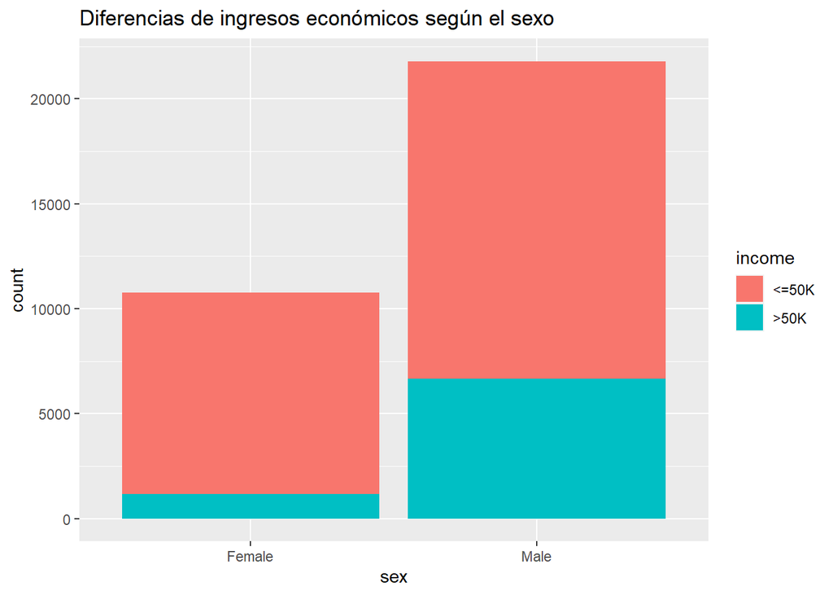

```r
# Visualizamos con la discretización del sexo según el atributo `income`.
ggplot(data=data_adult[1:filas,],
       aes(x = sex, fill = income)
       ) + geom_bar() + ggtitle("Diferencias de ingresos económicos según el sexo")
```

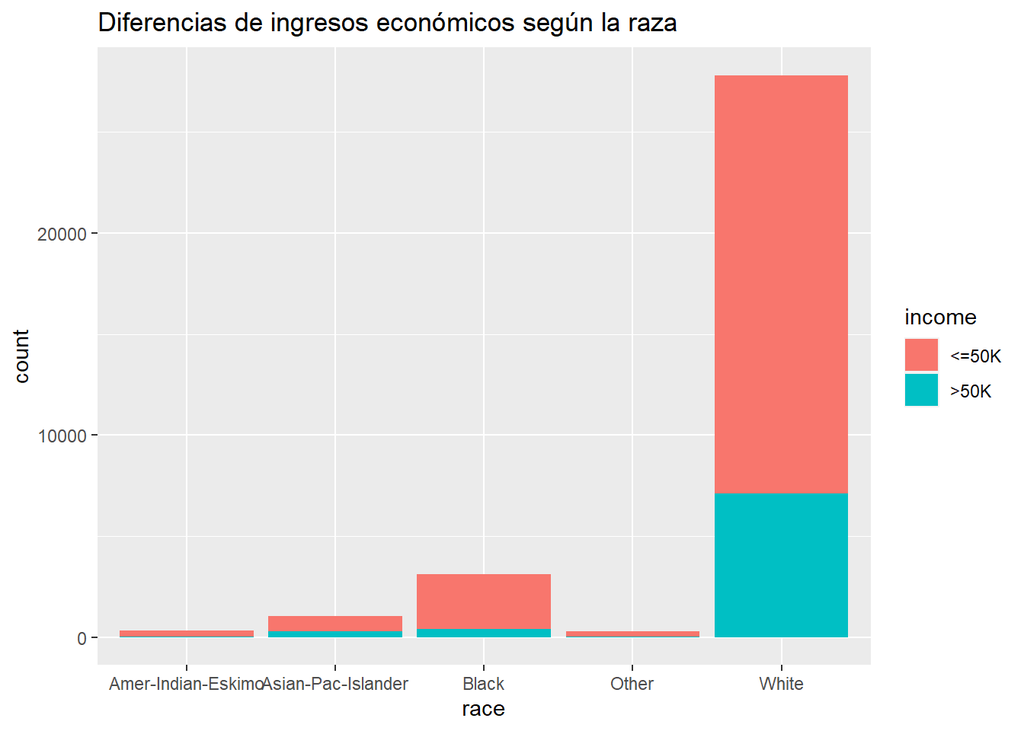

```r
# Visualizamos con la discretización de la "raza" según el atributo `income`.
ggplot(data=data_adult[1:filas,],
       aes(x = race, fill = income)
       ) + geom_bar() + ggtitle("Diferencias de ingresos económicos según la raza")
```

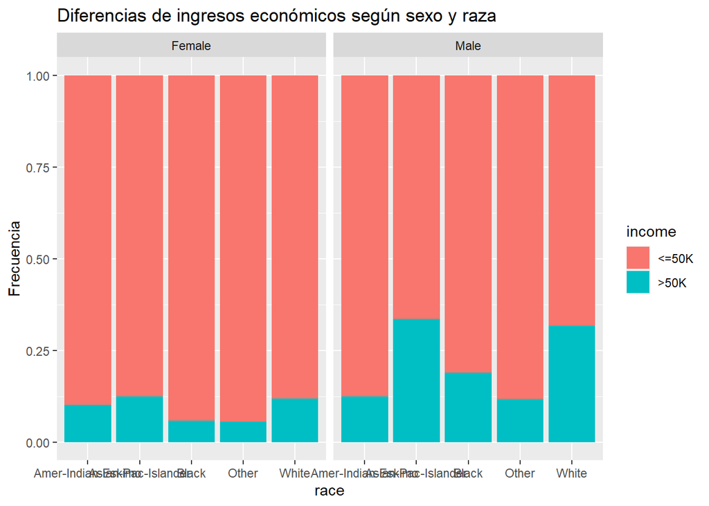

```r
# Creamos el gráfico con la función `ggplot`.
ggplot(data = data_adult[1:filas,],
       aes(x = race,
           fill= income
          )
) + geom_bar(position="fill") + ylab("Frecuencia")+  facet_wrap(~sex) +
  ggtitle("Diferencias de ingresos económicos según sexo y raza")
```

Otro atributo interesante a analizar es “workclass” (el cual hace referencia a los distintos tipos de trabajo). Este atributo lo podemos relacionar con otros y visualizar el resultado para sacar conclusiones:

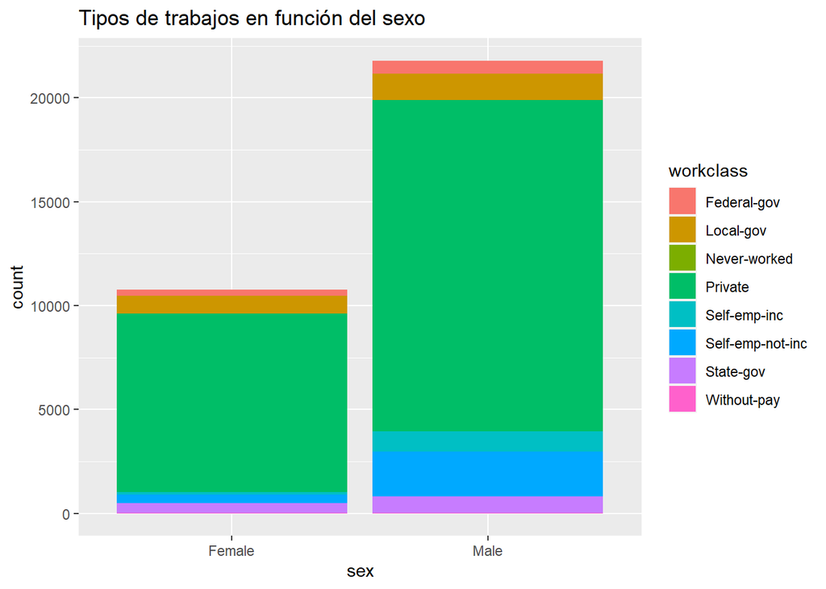

```r
# Visualizamos la frecuencia del sexo según el atributo `workclass`
ggplot(data = data_adult[1:filas,],
       aes(x = sex, fill = workclass)
       ) + geom_bar() + ggtitle("Tipos de trabajos en función del sexo")
```

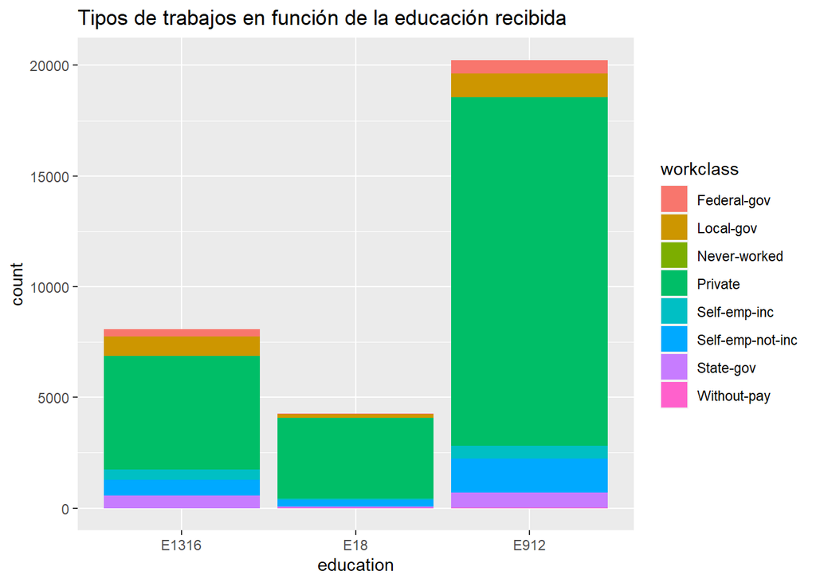

```r
# Visualizamos la educación según el atributo `workclass`.
ggplot(data = data_adult[1:filas,],
       aes(x = education, fill = workclass)
       ) + geom_bar() + ggtitle("Tipos de trabajos en función de la educación recibida")
```

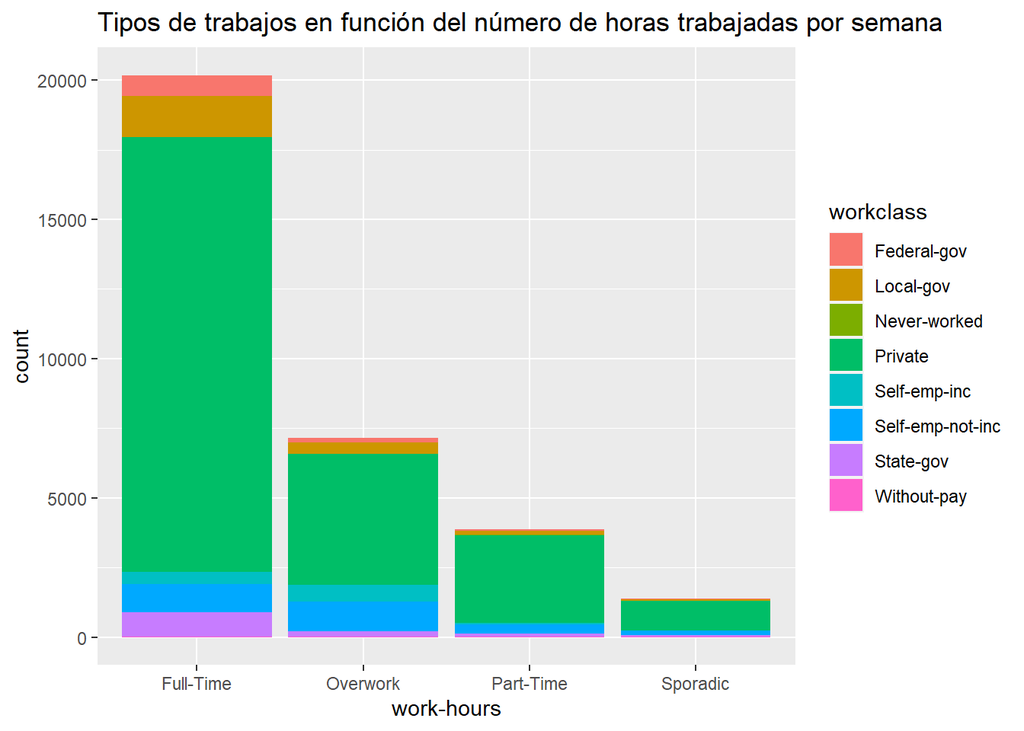

```r
# Visualizamos la columna "work-hours" según el atributo `workclass`.
ggplot(data = data_adult[1:filas,],
       aes(x = `work-hours`, fill = workclass)
       ) + geom_bar() + ggtitle("Tipos de trabajos en función del número de horas trabajadas por semana")
```